# Case_Study_2

David Shaw

8/12/2019

# Classifying Attrition

Our goal in this study is to use the available data to best identify which factors lead to worker attrition.

We read in the data here, and perform some early data exploration. We reclassify the Attrition variable to a binary numeric data type, and log transform the Monthly Income, Distance from Home, and Total Working Years since normality is a requirement for linear regression. We also drop certain columns that have no explanatory power - employee count is an ID variable, and Over18, EmployeeCount, and StandardHours have no variation.

Fortunately, there are no missing values that need accounting for.

```r
# Read in data
library(data.table, quietly=T)
library(MASS, quietly=T)
library(caret)
library(pROC)
library(fastDummies)
library(dplyr, quietly=T)
```

```r
library(readxl)
library(sjPlot)
library(ggplot2)

data <- fread('~/MSDS-6306-Doing-Data-Science/Unit 14/CaseStudy2-data.csv')

# Transformation: log transform MonthlyIncome, DistanceFromHome, TotalWorkingYears
data[, MonthlyIncome := log(MonthlyIncome)]
data[, DistanceFromHome := log(DistanceFromHome)]
data[, TotalWorkingYears := log(TotalWorkingYears+.5)]
# Turn Attrition into numeric binary
data[, Attrition := ifelse(Attrition=="Yes", 1, 0)]

# Look for columns with only 1 level
data[, lapply(.SD, function(x) {if(length(unique(x)) == 1 | length(unique(x)) == .N) x[1]})]
```

```
##    ID EmployeeCount EmployeeNumber Over18 StandardHours
## 1:  1             1            859      Y            80
```

```r
# Drop EmployeeCount, Over18, EmployeeNumber, StandardHours - not useful
data[, c("EmployeeCount", "Over18", "EmployeeNumber", "StandardHours") := NULL]

# Look for NAs - No NAs
any(is.na(data))
```

```
## [1] FALSE
```

```r
# Drop ID - don't need it for training, only for validation
data[, ID := NULL]
```

The first question of interest is whether we can predict the attrition variable using other explanatory tools at hand. I will consider two methods here - K nearest neighbors, and logistic regression.

We start off with 3 logistic regression models utilizing the forward, backward, and stepwise directions. After creating these fits, we pull the variables that are jointly significant between all 3 models to serve as a starting point for K nearest neighbors.

```r
#1) Predict attrition

# # First do stepwise logistic, to see if there are any common variables

data_names <- grep("Attrition|ID", names(data), invert=T, value=T)
data_names <- paste(data_names, collapse = "+")
form <- as.formula(paste0("Attrition~", data_names))

forward_mod <- step(glm(formula = form, data=data, family = 'binomial'), direction='forward', trace = 0)
backward_mod <- step(glm(formula = form, data=data, family = 'binomial'), direction='backward', trace=0)
step_mod <- step(glm(formula = form, data=data, family = 'binomial'), direction='both', trace=0)

# Looks like backward and stepwise models are identical
all.equal(backward_mod, step_mod)
```

```
## [1] TRUE
```

```r
# Grab significant variables
forward_vars <- summary(forward_mod)$coefficients[,4]
forward_sig_vars <- names(forward_vars[forward_vars < .05/3])
backward_vars <- summary(backward_mod)$coefficients[,4]
backward_sig_vars <- names(backward_vars[backward_vars<.05/3])

# Find intersection
intersect(forward_sig_vars, backward_sig_vars)
```

```
##  [1] "BusinessTravelTravel_Frequently" "DistanceFromHome"
##  [3] "EnvironmentSatisfaction"         "JobInvolvement"
##  [5] "JobSatisfaction"                 "MaritalStatusSingle"
##  [7] "NumCompaniesWorked"              "OverTimeYes"
##  [9] "RelationshipSatisfaction"        "TotalWorkingYears"
## [11] "TrainingTimesLastYear"           "WorkLifeBalance"
## [13] "YearsSinceLastPromotion"
```

```r
# From this, let's grab the commonly significant variables for KNN

vars_for_knn <- c('BusinessTravel', 'DistanceFromHome', 'EnvironmentSatisfaction', 'JobInvolvement', 'JobSatisfaction', 'MaritalStatus', 'NumCompaniesWorked', 'OverTime', 'RelationshipSatisfaction', 'TotalWorkingYears', 'WorkLifeBalance', 'YearsSinceLastPromotion')
```

Before running our KNN model, we need one last bit of data wrangling. KNN cannot handle categorical or factor variables, so the 3 we have here - business travel frequency, marital status, and over time pay - must be recoded to numeric binary variables.

Since only one level of each of these variables was significant in the earlier models, we will group together the “Married” and “Divorced” marital status groups, as well as the “Travel Rarely” and “Non Travel” travel frequency groups.

```r
# Make dummy columns for KNN
knn_subset <- data[, .SD, .SDcols=c("Attrition", vars_for_knn)]
knn_subset <- fastDummies::dummy_cols(knn_subset, select_columns=c("BusinessTravel", "MaritalStatus", "OverTime"))
knn_subset[, c("BusinessTravel", "MaritalStatus", "OverTime", "BusinessTravel_Travel_Rarely", "BusinessTravel_Non-Travel", "MaritalStatus_Divorced","MaritalStatus_Married", "OverTime_No") := NULL]

vars_for_knn <- grep("Attrition", names(knn_subset), invert=T, value=T)

knn_form <- as.formula(paste0("Attrition ~ ", paste(vars_for_knn, collapse = "+")))
```

Now we are ready for KNN. We begin by creating a training and a test data set, with 60% of the observations in the training set.

In order to determine the optimal k, we fit the KNN model for all values of k between 1 and 20.

```r
# Make test and training sets
set.seed(10)
training <- sample(1:nrow(knn_subset), size=round(0.6*nrow(knn_subset)))
test <- setdiff(knn_subset[, .I], training)
train_set <- knn_subset[training, .SD, .SDcols=vars_for_knn]
test_set <- knn_subset[test, .SD, .SDcols= vars_for_knn]
# Labels
cl <- knn_subset[training, Attrition]
true_labs <- knn_subset[test, Attrition]

# Fit KNN model
# Test various k's
for (k in 1:20) {
  temp_fit <- caret::knnreg(x=train_set, y=cl, k=k)
  predicted <- predict(temp_fit, test_set)
  pred2 <- ifelse(predicted <= .1609195, 0, 1)
  num_incorrect <- sum(pred2 != true_labs)
  misclass <- round(num_incorrect / nrow(test_set), digits=3)
  print(paste0("k = ", k, "; misclassification=", misclass))
}
```

```
## [1] "k = 1; misclassification=0.213"
## [1] "k = 2; misclassification=0.261"
## [1] "k = 3; misclassification=0.336"
## [1] "k = 4; misclassification=0.388"
## [1] "k = 5; misclassification=0.44"
## [1] "k = 6; misclassification=0.443"
## [1] "k = 7; misclassification=0.253"
## [1] "k = 8; misclassification=0.27"
## [1] "k = 9; misclassification=0.302"
## [1] "k = 10; misclassification=0.33"
## [1] "k = 11; misclassification=0.365"
## [1] "k = 12; misclassification=0.399"
## [1] "k = 13; misclassification=0.253"
## [1] "k = 14; misclassification=0.284"
## [1] "k = 15; misclassification=0.293"
## [1] "k = 16; misclassification=0.313"
## [1] "k = 17; misclassification=0.348"
## [1] "k = 18; misclassification=0.362"
## [1] "k = 19; misclassification=0.276"
## [1] "k = 20; misclassification=0.287"
```

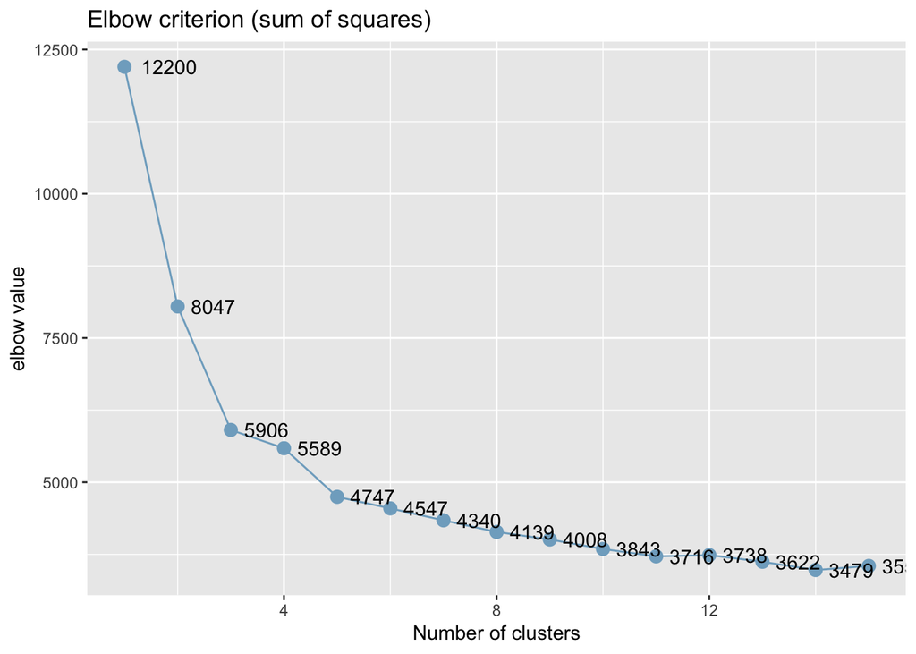

```r
# Elbow plot
sjc.elbow(train_set, steps=15)
```

```r
# Fit both k=1 and k=3 classification
knn1fit <- caret::knnreg(x=train_set, y=cl, k=1)
knn3fit <- caret::knnreg(x=train_set, y=cl, k=3)
```

We see the lowest misclassification rate at k=1, while the elbow plot shows k=3 to be a more suited k-value for analysis. Upon examining the sensitivity and specificity of our predictions, it appears our Nearest Neighbor model was overly “pessimistic,” correctly identifying almost all non-responses and missing 3/4 of the successes. By contrast, the k=3 model has much more balanced sensitivity and specificity results.

```r
# Error analysis
confusion <- data.table(
  true_labels = true_labs,
  predicted_k1 = ifelse(predict(knn1fit, test_set) <= .1609, 0, 1), # Use .1609 as a prior since that is the distribution of Attrition in original data
  predicted_k3 = ifelse(predict(knn3fit, test_set) <= .1609, 0, 1)
)

knn_fits <- data.table(
  measure = c("k1 sensitivity", "k1 specificity", "k1 error", "k3 sensitivity", "k3 specificity", "k3 error"),
  values = c(nrow(confusion[predicted_k1 == 1 & true_labels==1]) / nrow(confusion[true_labels==1]),
             nrow(confusion[predicted_k1 == 0 & true_labels==0]) / nrow(confusion[true_labels==0]),
             nrow(confusion[predicted_k1 != true_labels]) / nrow(confusion),
             nrow(confusion[predicted_k3 == 1 & true_labels==1]) / nrow(confusion[true_labels==1]),
             nrow(confusion[predicted_k3 == 0 & true_labels==0]) / nrow(confusion[true_labels==0]),
             nrow(confusion[predicted_k3 != true_labels]) / nrow(confusion)
             )
)

knn_fits
```

```
##           measure    values
## 1: k1 sensitivity 0.2500000
## 2: k1 specificity 0.8733333
## 3:       k1 error 0.2126437
## 4: k3 sensitivity 0.4583333
## 5: k3 specificity 0.6966667
## 6:       k3 error 0.3362069
```

Neither of these models demonstrate enough explanatory power to be useful predictors of job attrition. Neither can correctly identify more than 50% of the positives and negative responses, so we will look at alternatives.

Returning to our initial variable selection process, we will use those selected variables in a logistic regression, and remake the same confusion table to recalculate sensitivity and specificity.

The assumptions for multivariate logistic regression are a multivariate normal distribution across explanatory variables and independence. We have already addressed some of the normality concerns in the data, but the multivariate central limit theorem also ensures some robustness against this assumption. There is no reason to suspect lack of independence in the data sampling procedure, so we consider this assumption met as well.

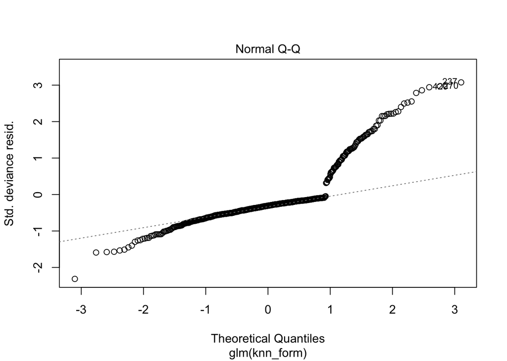

```r
# Logit predict
log_mod <- glm(formula = knn_form, data= knn_subset[training], family='binomial')
plot(log_mod, 2)
```

```r
confusion <- data.table(
  true_labels = true_labs,
  predicted = ifelse(predict(log_mod, test_set, type='response') <= .1609, 0, 1)
)

logit_fit <- data.table(
  fit_statistic = c("Sensitivity", "Specificity", "Error", "AIC"),
  value = c(nrow(confusion[predicted ==1 & true_labels==1]) / nrow(confusion[true_labels==1]),
            nrow(confusion[predicted == 0 & true_labels==0]) / nrow(confusion[true_labels==0]),
            nrow(confusion[predicted != true_labels]) / nrow(confusion),
            extractAIC(log_mod)[2])
)

logit_fit
```

```
##    fit_statistic       value
## 1:   Sensitivity   0.8333333
## 2:   Specificity   0.7333333
## 3:         Error   0.2528736
## 4:           AIC 359.4533647
```

We see that the logistic model does a much better job of predicting attrition, correctly identifying 83% of the attrition=yes responses and 73% of the attrition=No responses. The ROC plot and area under the curve statistic do not suggest fantastic explanatory power in general, but considering how well our model fits the test set, we will move forward with this logistic regression model.

```r
summary(log_mod)
```

```
##
## Call:
## glm(formula = knn_form, family = "binomial", data = knn_subset[training])
##
## Deviance Residuals:
##     Min       1Q   Median       3Q      Max
## -2.2720  -0.5202  -0.3030  -0.1400   3.0714
##
## Coefficients:
##                                  Estimate Std. Error z value Pr(>|z|)
## (Intercept)                       3.88693    1.13518   3.424 0.000617 ***
## DistanceFromHome                  0.21216    0.14076   1.507 0.131762
## EnvironmentSatisfaction          -0.31217    0.13162  -2.372 0.017708 *
## JobInvolvement                   -0.47277    0.18985  -2.490 0.012767 *
## JobSatisfaction                  -0.46170    0.13207  -3.496 0.000472 ***
## NumCompaniesWorked                0.23155    0.05747   4.029 5.61e-05 ***
## RelationshipSatisfaction         -0.24963    0.12949  -1.928 0.053878 .
## TotalWorkingYears                -1.64532    0.24436  -6.733 1.66e-11 ***
## WorkLifeBalance                  -0.31872    0.18918  -1.685 0.092047 .
## YearsSinceLastPromotion           0.21153    0.05202   4.066 4.78e-05 ***
## BusinessTravel_Travel_Frequently  0.33023    0.35138   0.940 0.347319
## MaritalStatus_Single              1.17874    0.29007   4.064 4.83e-05 ***
## OverTime_Yes                      1.76102    0.28973   6.078 1.22e-09 ***
## ---
## Signif. codes:  0 '***' 0.001 '**' 0.01 '*' 0.05 '.' 0.1 ' ' 1
##
## (Dispersion parameter for binomial family taken to be 1)
##
##     Null deviance: 486.14  on 521  degrees of freedom
## Residual deviance: 333.45  on 509  degrees of freedom
## AIC: 359.45
##
## Number of Fisher Scoring iterations: 6
```

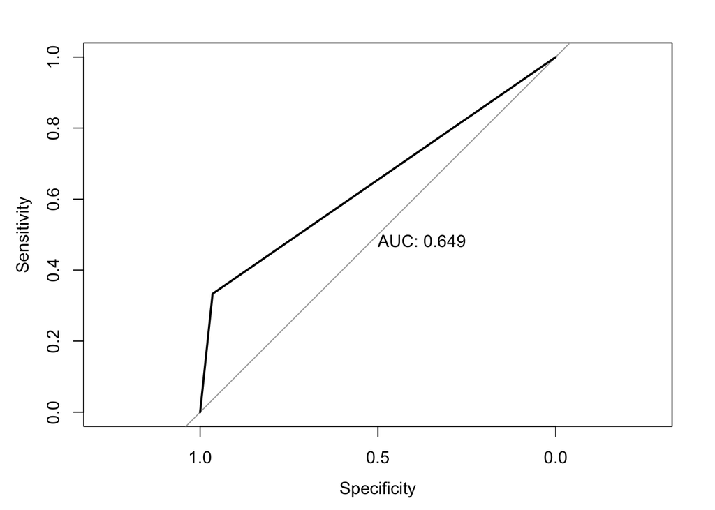

```r
roc_obj <- pROC::roc(response=confusion$predicted, predictor = confusion$true_labels, plot=T, xlim = c(1, 0), print.auc=T)
```

From examining the summary of the logistic model, we see that the strongest indicators of attrition, judging by the p-values, are the total number of working years, whether the worker gets overtime or not, and the number of years since his/her last promotion.

```r
# Predict missing values
validation_set_attrition <- fread("~/MSDS-6306-Doing-Data-Science/UNIT 14/CaseStudy2CompSet No Attrition.csv")

# Apply transformations
validation_set_attrition[, DistanceFromHome := log(DistanceFromHome)]
validation_set_attrition[, TotalWorkingYears := log(TotalWorkingYears + 0.5)]
validation_set_attrition <- fastDummies::dummy_cols(validation_set_attrition, select_columns = c("BusinessTravel", "MaritalStatus", "OverTime"))
validation_set_attrition[, c("BusinessTravel", "MaritalStatus", "OverTime", "BusinessTravel_Travel_Rarely", "BusinessTravel_Non-Travel", "MaritalStatus_Divorced","MaritalStatus_Married", "OverTime_No") := NULL]

validation_preds <- predict(log_mod, validation_set_attrition, type='response')
output <- data.table(ID=validation_set_attrition$ID,Attrition = ifelse(validation_preds <= .1609, "No", "Yes"))
fwrite(output, "~/dds_casestudy_2/Case2PredictionsShaw Attrition.csv")
```

# Predicting Monthly Salary

Our goal in this study is to use available data to best predict a worker’s monthly salary. We’ll use the same dataset as for analysis of worker attrition, with the same initial data transformations.

We’ll begin by doing a similar procedure as we did in predicting attrition. With such a wide array of potential explanatory variables, we will begin by using stepwise selection techniques, and look at the commonly significant variables.

```r
forward_mod <- step(glm(formula = MonthlyIncome ~ ., data=data), direction='forward', trace=0)
backward_mod <- step(glm(formula = MonthlyIncome ~ ., data=data), direction='backward', trace=0)
step_mod <- step(glm(formula = MonthlyIncome ~ ., data=data), direction='both', trace=0)

# Again, backward and stepwise models exactly agree
all.equal(backward_mod, step_mod)
```

```
## [1] TRUE
```

```r
# Pull jointly significant variables
forward_vars <- summary(forward_mod)$coefficients[,4]
forward_sig_vars <- names(forward_vars[forward_vars < .05/3])
backward_vars <- summary(backward_mod)$coefficients[,4]
backward_sig_vars <- names(backward_vars[backward_vars<.05/3])

# Find intersection
intersect(forward_sig_vars, backward_sig_vars)
```

```
## [1] "(Intercept)"                  "JobLevel"
## [3] "JobRoleLaboratory Technician" "JobRoleManager"
## [5] "JobRoleResearch Director"     "JobRoleResearch Scientist"
## [7] "JobRoleSales Representative"  "TotalWorkingYears"
```

From our stepwise selection methods, the jointly significant predictors appear to be job level, job role, and the total number of working years.

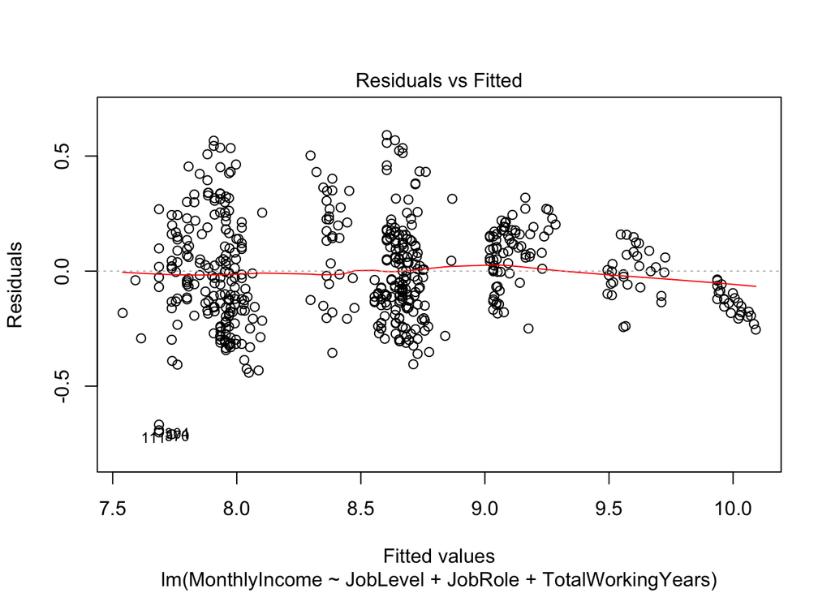

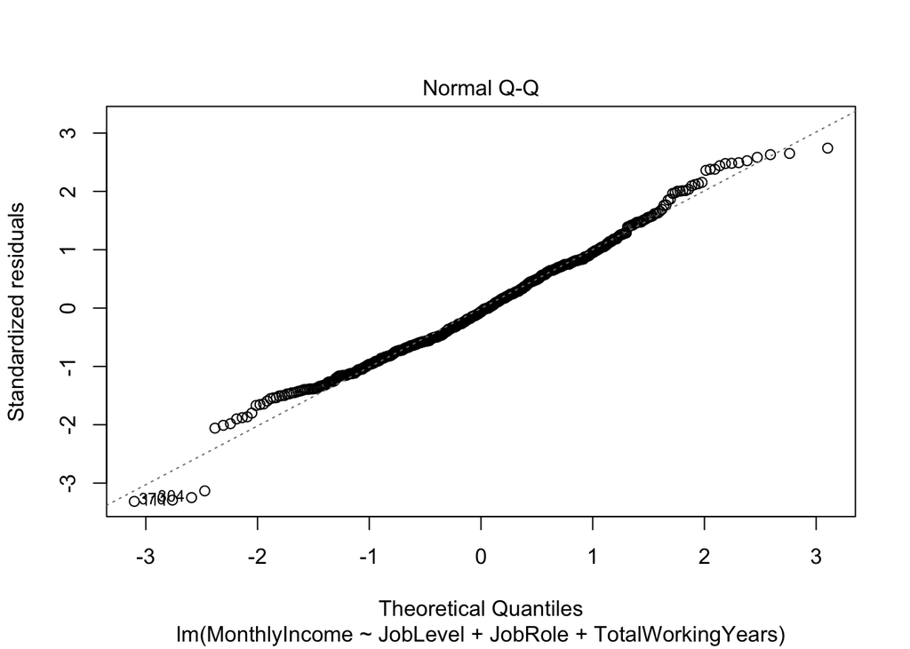

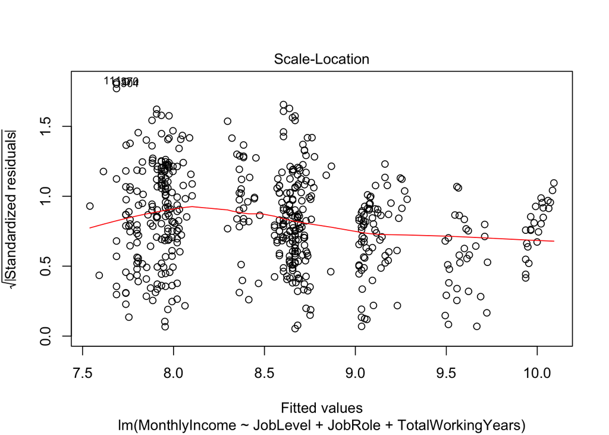

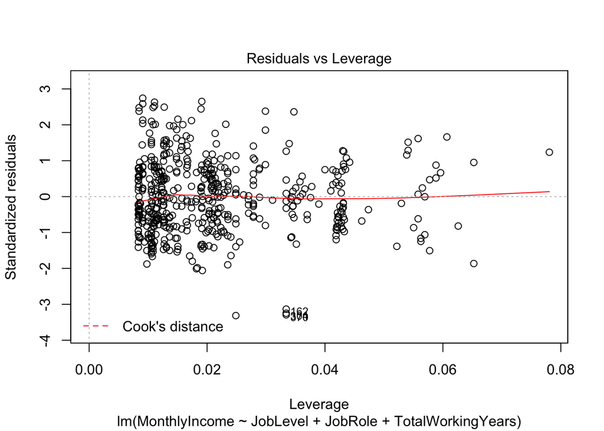

```r
# Make test and training sets
set.seed(10)
training <- sample(1:nrow(data), size=round(0.6*nrow(data)))
train_set <- data[training, ]
test_set <- data[-training, ]

linear_mod <- lm(data=train_set, formula = MonthlyIncome ~ JobLevel + JobRole + TotalWorkingYears)

# Plot residuals
plot(linear_mod)
```

The assumptions for multiple linear regression are normality of residuals, homoscedasticity, independence, lack of autocorrelation, and lack of multicollinearity. The residuals plot shows little evidence of any trend in the residuals, and the residuals appear to share a normal distribution across all values of leverage. Additionally, there are very few outliers in this dataset.

There is no reason to suspect any independence, or autocorrelation. We can test for multicollinearity between our two numeric explanatory variables, by plotting the two against each other.

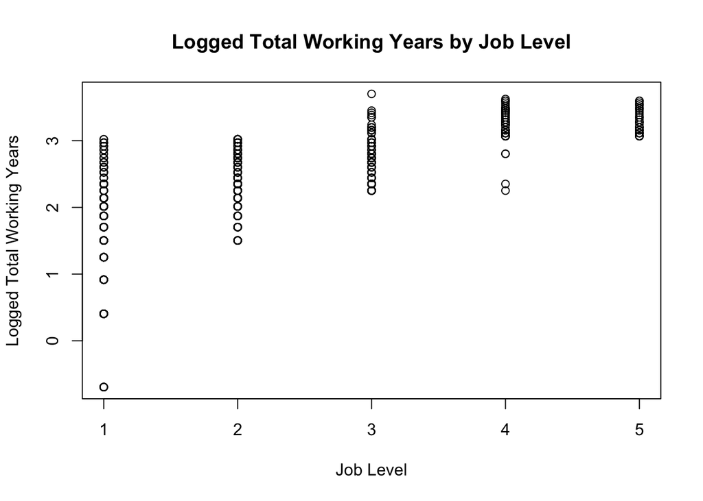

```r
plot(data$JobLevel, data$TotalWorkingYears, main="Logged Total Working Years by Job Level", xlab="Job Level", ylab="Logged Total Working Years")
```

There may be some evidence of a trend between job level and the logged total working years, but there isn’t any conclusive proof we can draw from this plot of a linear relationship. Additionally, there is clear heteroscedasticity in this linear relationship, so the assumptions for linear regression between these two variables are violated. We will assume we have satisfied the lack of multicollinearity assumption.

The final model:

```r
summary(linear_mod)
```

```
##
## Call:
## lm(formula = MonthlyIncome ~ JobLevel + JobRole + TotalWorkingYears,
##     data = train_set)
##
## Residuals:
##      Min       1Q   Median       3Q      Max
## -0.70871 -0.14723 -0.01418  0.14473  0.59104
##
## Coefficients:
##                                Estimate Std. Error t value Pr(>|t|)
## (Intercept)                    7.642865   0.058645 130.324  < 2e-16 ***
## JobLevel                       0.365041   0.019560  18.663  < 2e-16 ***
## JobRoleHuman Resources        -0.322336   0.063877  -5.046 6.27e-07 ***
## JobRoleLaboratory Technician  -0.324104   0.044725  -7.247 1.59e-12 ***
## JobRoleManager                 0.059726   0.063052   0.947   0.3440
## JobRoleManufacturing Director -0.003645   0.041857  -0.087   0.9306
## JobRoleResearch Director       0.144500   0.057680   2.505   0.0125 *
## JobRoleResearch Scientist     -0.301012   0.043941  -6.850 2.12e-11 ***
## JobRoleSales Executive        -0.017632   0.035826  -0.492   0.6228
## JobRoleSales Representative   -0.375417   0.054024  -6.949 1.13e-11 ***
## TotalWorkingYears              0.133177   0.017772   7.494 2.97e-13 ***
## ---
## Signif. codes:  0 '***' 0.001 '**' 0.01 '*' 0.05 '.' 0.1 ' ' 1
##
## Residual standard error: 0.2166 on 511 degrees of freedom
## Multiple R-squared:  0.8899, Adjusted R-squared:  0.8877
## F-statistic:   413 on 10 and 511 DF,  p-value: < 2.2e-16
```

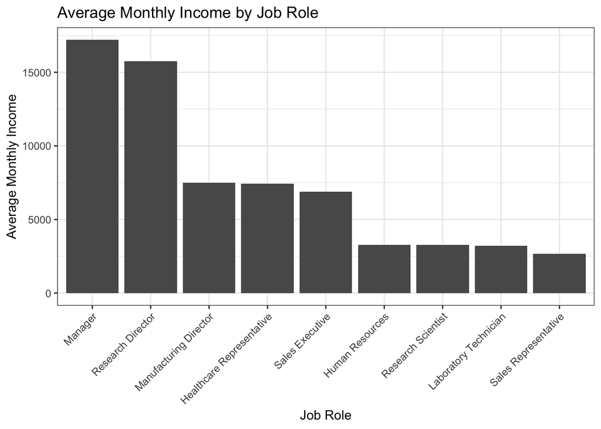

```r
ggplot(data=data[, mean(exp(MonthlyIncome)), by='JobRole'], aes(x=reorder(JobRole, -V1), y=V1)) +
  geom_bar(stat='identity') +
  theme_bw() +
  xlab("Job Role") +
  ylab("Average Monthly Income") +
  theme(axis.text.x = element_text(angle=45, hjust=1)) +
  ggtitle("Average Monthly Income by Job Role")
```

We see positive correlation between job level and total working years, as expected. Looking at the average monthly salary by job role, we see roughly 3 tiers of salaries, which could be interesting. The drop offs from research directors to manufacturing directors and from sales executives to human resources are much larger than any other drop offs.

The next step is to fit our model to our test dataset, and examine the fit statistics.

```r
lin_output <- data.table(
  predicted = exp(predict(linear_mod, test_set)),
  actual = exp(test_set$MonthlyIncome)
)

# Fit statistics
fits <- data.table(
  measure = c("Adjusted R Squared", "AIC", "RMSE"),
  value = c(summary(linear_mod)$adj.r.squared, extractAIC(linear_mod)[2], sqrt(sum(lin_output[, (predicted - actual)^2])/nrow(lin_output)))
)

fits
```

```
##               measure         value
## 1: Adjusted R Squared     0.8877335
## 2:                AIC -1586.3592386
## 3:               RMSE  1253.7643476
```

```r
income_validation <- readxl::read_excel("~/MSDS-6306-Doing-Data-Science/UNIT 14/CaseStudy2CompSet No Salary.xlsx") %>% as.data.table

income_validation[, TotalWorkingYears := log(TotalWorkingYears + 0.5)]

# Output set - don't forget to antilog the predicted monthly income
income_output <- data.table(
  ID = income_validation$ID,
  MonthlyIncome = exp(predict(linear_mod, income_validation))
)

fwrite(income_output, "~/dds_casestudy_2/Case2PredictionsShaw MonthlyIncome.csv")
```

# Conclusion

In addressing the questions of interest, we found that the best predictors of worker attrition are the total number of working years, whether the worker gets overtime or not, and the number of years since his/her last promotion. Using this model, we were able to correctly identify 83% of the workers who left and 73% of the workers who stayed. We see that non-overtime-exempt workers and workers who have not been promoted in a while are more likely to leave, and that employees who have been in the workforce longer are less likely to leave.

The best predictors for the monthly income are the employee’s job role, job level, and total working years. Unsurprisingly, higher job levels and longer-tenured employees generally earn a higher monthly income.

# Appendix

In the course of investigating the questions of interest, here are some more trends that may be useful.

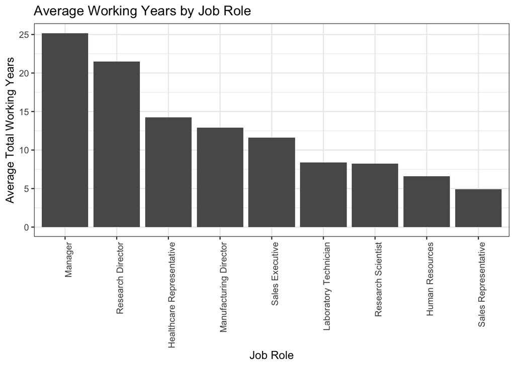

```r
# Miscellaneous findings
# Average working years by Job Role - take exponent since we took log transform earlier
ggplot(data=data[, mean(exp(TotalWorkingYears)), by='JobRole'], aes(x=reorder(JobRole, -V1), y=V1)) +
  geom_bar(stat='identity') +
  theme_bw() +
  xlab("Job Role") +
  ylab("Average Total Working Years") +
  theme(axis.text.x = element_text(angle=90, hjust=1)) +
  ggtitle("Average Working Years by Job Role")
```

Unsurprisingly, executives, managers, and directors tend to be the longest tenured employees. Interestingly, health care representatives are the 3rd longest tenured class of employees on average, compared to sales representatives who are the shortest tenured employees.

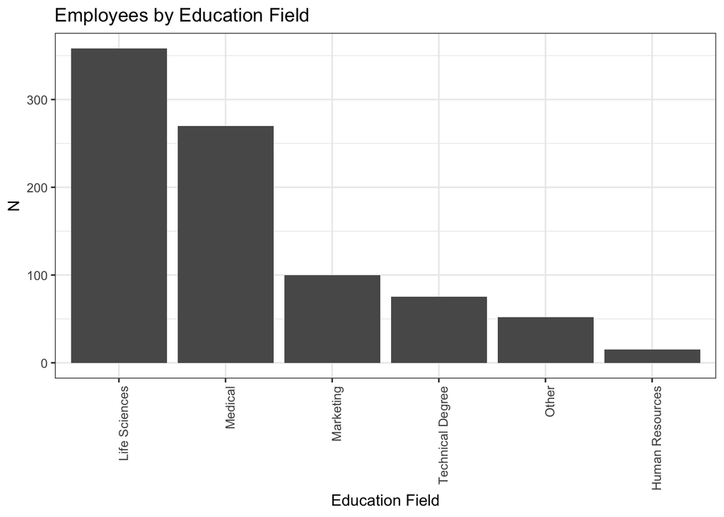

```r
# Employees by Education Field
ggplot(data=data[, .N, by='EducationField'], aes(x=reorder(EducationField, -N), y=N)) +
  geom_bar(stat='identity') +
  theme_bw() +
  xlab("Education Field") +
  theme(axis.text.x = element_text(angle=90, hjust=1)) +
  ggtitle("Employees by Education Field")
```

The vast majority of employees studied eiher life sciences or a medical field, accounting for 72% of the employees.

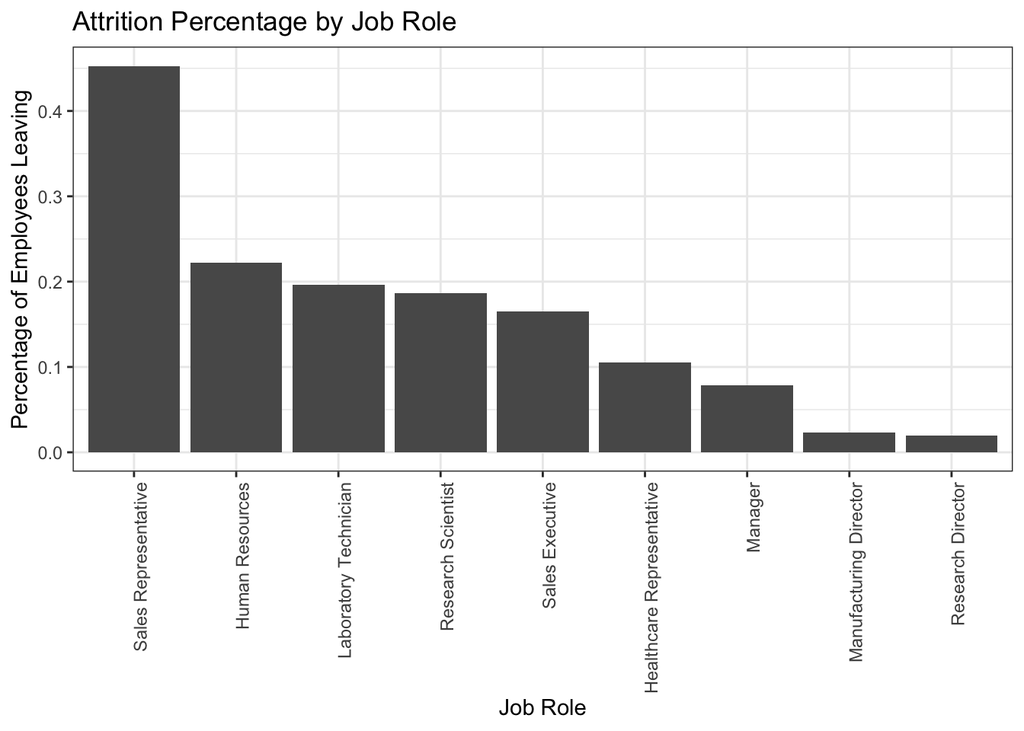

```r
# Attrition percentage by Job Role
ggplot(data=data[, sum(Attrition)/ .N, by='JobRole'], aes(x=reorder(JobRole, -V1), y=V1)) +
  geom_bar(stat='identity') +
  theme_bw() +
  xlab("Job Role") +
  ylab("Percentage of Employees Leaving") +
  theme(axis.text.x = element_text(angle=90, hjust=1)) +
  ggtitle("Attrition Percentage by Job Role")
```

Although the employee’s job role didn’t enter our predictive model for attrition, we see that the percentage of employees leaving varies between job roles. Sales representatives exhibit by far the highest turnover percentage.

Thank you for your attention! Please check out my guided presentation [here](https://youtu.be/Nu8fMSZ-4pU).